# Film Availability Highly Influential in Predicting Total Gross of Film

Jay Kim

October 25, 2014

## Introduction:

Film production and distribution is often seen as a highly risky investment. On average, such investments exceed millions of dollars, making measuring the risks and minimizing losses a neccesity within the industry. While distribution companies are unable to affect the film’s quality prior to release, they are able to control the loss through limiting promotions and availability within a region. As a result, distribution companies seek to create models based on prior data to find trends to identify films where risk is lowest and methods to maximize profits. Recognizing the factors responsible for these trends would allow distribution companies to manipulate the variables it can affect based on the film’s predicted success. What are these factors and to what extent can they be used to predict the success of a film?

Based on the available data, the study focused on the month, distributor, genre, and availability (number of theaters the film was presented in) of a specified movie. Within the film industry, there are known peak periods at which films thrive in, ex. summer blockbusters. Similarly, there are what are called “dump months” where films tend to perform poorly at the box office. Since it is difficult to identify when these peak and dump periods exist on an yearly basis, the study simply divided the films based on months. The genre of the film, such as comedy, documentary, and horror, also affect the film’s popularity and total gross earnings. Certain genres are known to attract large audiences such as action whereas other genres target a small but well established audience such as documentaries. There exists a high likelihood that there is some form of interaction between the distributor and the availability of the film as larger distributors have both the funds and connections to increase the theaters the film is shown in.

## Methods:

To obtain the model, the program R 3.1.1 was used with RStudio 0.98.1049. Data was gathered from the website www.the-numbers.com/box-office-chart/weekend/2014/10/10. A total of 200 films were used as data for the model that featured films in every month, with a total of 65 distributors responsible for the distribution of these films. The criteria for selecting these 200 films is random selection. The website gathered data directly from distributors.

The model was created with the variables genre, month, distributor, availability, and the interaction between availability and distributor.

$Total Gross= \beta_0 + \beta_1 Genre + \beta_2 Month + \beta_3 Distributor + \beta_4 Availability + \beta_5 Availability*Distributor$

To create the model, it was necessary to check the assumptions of a multiple regression model. To do so, a residual plot was created and checked for the absence of patterns to suggest normality. After observing any possible trends within the residual plot, a histogram of the raw data with the y variable as total gross was constructed. This plot was to check the overall shape of the data as well as note the existence of any possible influential points for future reference.

Adjusted variable plots and simple linear regressions of each term were then created to visualize and quantify the contribution of each term to the model’s accuracy. To detect any multicollinearity, a scatterplot matrix was created. To verify any influential points, plots of standardized residuals that displayed the leverage of each point were created (code shown in source file). Testing was also done to see if an error shown with the distributor interaction was unique to the interaction with availability or if it was intrinsic to the distributor variable itself, by creating several simple linear regressions with distributor interactions with month and the amount of days the film played in theaters. Any influential points will be discarded due to their influence on the data and the model’s accuracy.

## Discussion:

The p-value of the model is sufficiently low enough to reject the null hypothesis that the regression models’s accuracy is due to chance alone. The R squared value is .6527, which is adequate, meaning that it does not suggest overfitting nor does it present a lack of variables.

### Interpretation of Results

It is interesting to find that the availability of a film had the largest impact on total gross. This suggests that accounting for the other factors, which a distributor may recognize or control prior to release, a distributor can predict a film’s success based on how available it allows the film to be. Although there was a low adjusted R squared value for distributor, suggesting that the brand of the distributor is not by itself a critical factor in predicting total gross, the interaction of a distributor and availability is highly important. This hints that while predicting a film’s success from the distributor is unreliable, the distributor’s effect on the availability of a film has a serious effect on predicting the film’s success. The adjusted R square of month is also interesting as it shows that the month cannot explain the total gross of a film well, despite the dump month theory.

### Data and Model Limitations

The model also faces severe limitations. The interaction term of distributor and availability created several NA values for some observations. These NA values tended to coincide with the lesser known distributors such as Wolfe Releasing. Noting that these lesser known distributors are therefore not accounted for, there is a bias within the model towards distributors with more films in the data.

There were also negative values within the predicted values. Some films had negative total gross, even though this is not practically viable. These negative values occurred mostly in movies with low availability and small distributors. This was concerning and may be best explained by the low adjusted R squared value of the model and the lack of data for certain variables. As mentioned above, the extreme unequal distribution of data within variables made it difficult at times to obtain statistically significant variables at times. As a result, some coefficients did not accurately reflect the true coefficient of these variables, creating a noticable negative value. Such occurred specifically for movies with small distributors, as such distributors often have only a single film. This suggests that when movies with few similarities to other movies are introduced, the model may break down.

### Issues with the Interaction Term

The interaction term created difficulties as it faced an error when trying to measure collinearity with VIF (variance inflation factor). As a result, collinearity was measured with a scatterplot matrix. The scatterplot matrix both does not quantify collinearity to a point where it can be objectively determined and is missing two variables, months and the interaction term. The collinearities of these variables are thus unknown. Regardless of the collinearity issue the interaction term presented, the interaction term was still used for various reasons. The interaction term was statistically significant with a notable contribution to the adjusted R squared value. In terms of practical application, the inclusion of the interaction term makes logical sense. Furthermore, upon further testing, the collinearity issue occurred with any interaction with the distributor variable, suggesting that the problem does not exist with the usage of the term but rather due to the large amount of distributors present and the distribution of data within the distributors.

### Presence of Collinearity and Influential Points

The collinearity between availability and total gross and genre and total gross is not of major concern as it is across independent and dependent variables, rather than independent variables affecting each other and thus the model’s regression ability. It only suggests that there is some relationship between availability and total gross and genre and total gross, which is verified through the relatively high adjusted R squared values.

Observations 147, 69, and 70 were discarded due to the impact they had on the model. The observations did not reveal any unexpected characteristics that would’ve been noted and the absence of these observations increased the R squared value of the model by approximately 11%.

## Conclusion:

The model shows that the availability of the movie plays the largest role in predicting the total gross of the movie. The interaction between distributor and availability play the second largest role. These factors, which distributors are able to easily account for and control, allow greater insight into the strategies that distributors use to maximize profit. Through increasing availability of the films, distributors are better able to predict the success of a film. Through finding the large coefficients of genres and months, it becomes clearer as to why distributors target specific months and genres over others. Even though there is great variation between genres and months, certain genres and months have massive benefits relative to others. Although the model does explain certain strategies of distributors, it should be noted that the data was limited. That is, distributors often have access to more data that measure more variables. For future studies, it would be interesting to have access to such information to create a model based on factors that the industry uses, rather than ones available through a public website.

## Figures and Tables:

### Table 1

### Coefficients and P-Values of the Model

|  | Coefficients | p-values |
| --- | --- | --- |
| (Intercept) | -5822555.27 | 0.66 |
| month02 | -2627844.53 | 0.72 |
| month03 | 7486706.78 | 0.21 |
| month04 | -554907.82 | 0.92 |
| month05 | 314723.66 | 0.96 |
| month06 | 2503787.41 | 0.72 |
| month07 | 4799045.24 | 0.49 |
| month08 | 305049.51 | 0.97 |
| month09 | -2943020.85 | 0.67 |
| month10 | 2823066.86 | 0.64 |
| month11 | 10048010.21 | 0.20 |
| month12 | -9719395.56 | 0.20 |
| gensAdventure | 42029224.67 | 0.00 |
| gensBlack Comedy | 8107888.54 | 0.51 |
| gensComedy | 3257929.24 | 0.66 |
| gensDocumentary | 3533948.16 | 0.67 |
| gensDrama | 301798.06 | 0.97 |
| gensHorror | 2346239.71 | 0.78 |
| gensRomantic Comedy | 7276606.62 | 0.49 |
| gensThriller/Suspense | -461814.26 | 0.96 |
| gensWestern | -206986.90 | 0.99 |
| distr20th Century Fox | -4924006.75 | 0.76 |
| distrABCKO Films | 5127685.18 | 0.75 |
| distrAbramorama Films | 683124.78 | 0.97 |
| distrAmerican Experience/PBS Films | 5158961.60 | 0.72 |
| distrArchstone Entertainment | 6788800.17 | 0.68 |
| distrArclight Films | -6723041.20 | 0.68 |
| distrArtMattan Productions | -5247478.85 | 0.72 |
| distrBig World Pictures | -29414.75 | 1.00 |
| distrBond/360 | 1315861.74 | 0.91 |

[output cut: 100 more lines]

### Table 2

### Adjusted R Squares and P-Values of the SLR per Variable

| **Variable** | **P value** | **Adjusted R Squared** |
| --- | --- | --- |
| Month | 0.3022 | 0.009938 |
| Availability | 2.2e-16 | 0.4892 |
| Availability and Distributor | 0.0001524 | 0.386 |
| Distributor | 0.4445 | 0.009694 |
| Genre | 1.89e-07 | 0.1884 |

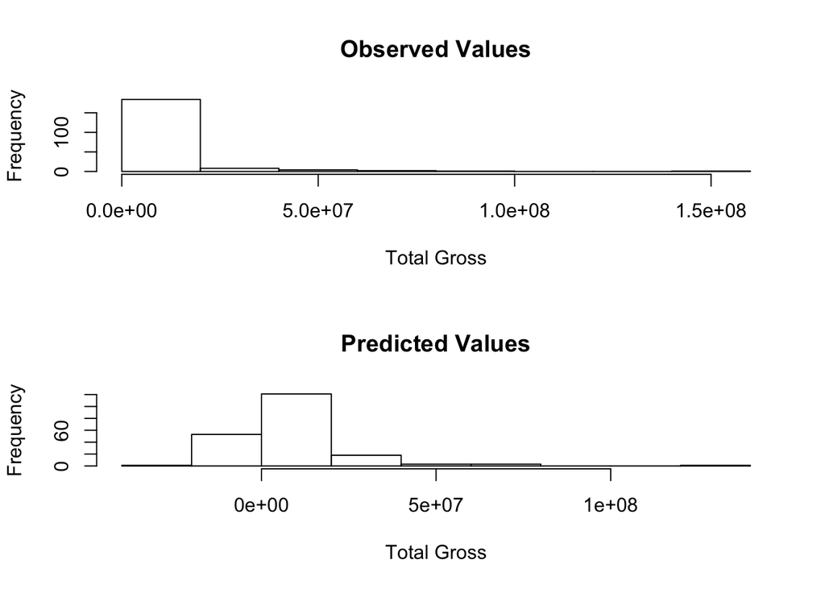

### Figure 1

## References:

http://www.statmethods.net/stats/rdiagnostics.html

http://vegasseven.com/2013/01/03/cinematic-dumpster-dive/